# TRATAMIENTO DE DATOS CON R

Joaquín Planelles Romero e Isabel Padilla Sánchez

octubre de 2021

# **Librería dplyr**

Como hemos visto, los paquetes de tidyverse son interoperables y tienen una misma filosofía (uso de tuberías y datos ordenados). En esta unidad vamos a trabajar con la librería dplyr que proporciona un conjunto de rutinas específicas para manipular datos que tienen que cumplir un requisito esencial, han de ser datos rectangulares,es decir, organizados en filas y columnas. Esto tiene consecuencias beneficiosas para nosotros, (1) se opera de forma rápida y (2) se tiene un lenguaje de programación mucho más legible.

Para empezar a trabajar con dplyr, es fundamental tener a mano la [chuleta](https://github.com/rstudio/cheatsheets/raw/master/data-transformation.pdf) que puedes encontrar en la propia web de tidyverse. Está organizada dependiendo de que el comando se utilice para manipular filas (casos) o columnas (variables), es decir, si queréis operar con filas, tendréis que ir a la columna de la chuleta denominada **‘Manipulate Cases’** y si lo hacéis con las columnas, encontraréis el comando necesario en **‘Manipulate Variables’**. En esta unidad nos vamos a centrar en los principales comandos de este paquete.

Como ya se ha visto, dplyr forma parte del núcleo de tidyverse, por tanto, cuando se ejecuta `library(tidyverse)`, dplyr queda cargada. Pero si solo queremos instalar esta librería, tenemos que ejecutar la siguiente línea ya que se encuentra en el repositorio R CRAN:

```r
install.packages("dplyr")
library(dplyr)
```

[figure not shown]

# **Manipulación de columnas**

En esta sección os vais a familiarizar con los principales comandos de dplyr para operar con las columnas de un tibble/data.frame. En este sentido, hay dos comandos principales para trabajar por columnas: los comandos `select()` y `mutate()`.

En los próximos apartados haremos referencia a estos y a otros comandos. No obstante, es frecuente que antes de ponerte a programar, te interese realizar un análisis exploratorio de tus datos. Y para ello, hay dos comandos que son particularmente útiles: `glimpse()` y `head()`.

En esta unidad vamos a usar un data.frame con un listado de productos de ikea, extraído del repositorio de ‘tidytuesday’, del que ya os hablamos en la guía del curso. Para cargar los datos en R, corre las siguientes líneas de código en tu consola de Rstudio:

```r
library(tidyverse)
ikea <- readr::read_csv('https://raw.githubusercontent.com/rfordatascience/tidytuesday/master/data/2020/2020-11-03/ikea.csv')
```

Ahora ya puedes explorar tus datos. Para ello, utiliza en R los mencionados comandos glimpse(ikea) y head(ikea). ¿Sabrías identificar en qué se diferencian? ¿Y qué pasa si optas por View(ikea)?

En la siguiente tabla puedes encontrar la descripción en español de las variables que contiene el data.frame ‘ikea’ que acabas de cargar y que utilizaremos en el resto de la sección:

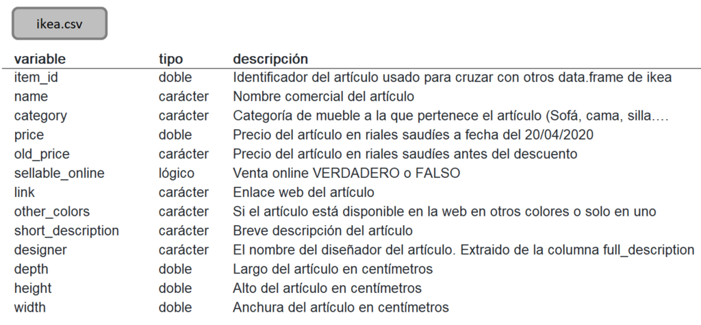

# Manipulación de columnas. 1 - select

El comando `select()` es uno de los más utilizados en el tratamiento de datos ya que nos permite seleccionar un subconjunto de columnas del tibble. Como vemos en la tabla existen dos formas de escribir la misma sentencia. Nosotros, en lo sucesivo, vamos a optar por la segunda, es decir, usando tuberías ya que es más clara la secuencia de acciones ejecutadas sobre los datos.

Comando

Utilidad

Descripción

`tabla <- select(datos, columna1, columna2)`  
ó  
`tabla <- datos %>% select(columna1, columna2)`

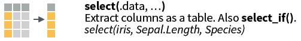

Seleccionamos las columnas que indicamos en el select().

Supongamos que del fichero **ikea** nos interesan solo las columnas que hacen referencia al identificador del artículo, al nombre y la categoría a la que pertenece dicho artículo, es decir, queremos un nuevo tibble que contenga item_id, name y category.

```r
Ejemplo <- ikea %>% select(item_id, name, category)
head(Ejemplo)
```

```
## # A tibble: 6 x 3
##    item_id name                  category
##      <dbl> <chr>                 <chr>
## 1 90420332 FREKVENS              Bar furniture
## 2   368814 NORDVIKEN             Bar furniture
## 3  9333523 NORDVIKEN / NORDVIKEN Bar furniture
## 4 80155205 STIG                  Bar furniture
## 5 30180504 NORBERG               Bar furniture
## 6 10122647 INGOLF                Bar furniture
```

Sencillo ¿verdad? `select()` **‘selecciona’** las variables que le indicamos sin más.

# Manipulación de columnas. 2 - mutate

Con la función `mutate()` podemos generar nuevas variables en nuestro conjunto de datos. Como caso particular, si a la nueva variable le damos el mismo nombre que ya tenía una variable preexistente, lo que haremos será machacar/transformar la variable que teníamos. Es así uno de los comandos más usados en el tratamiento de datos. mutate() trabaja de forma vectorial. ¿Qué significa esto? Que la función que estás aplicando genera un nuevo valor para cada registro (fila) de tu data.frame, teniendo por tanto la nueva variable la misma dimensión que el resto de las variables de tu conjunto de datos.

Comando

Utilidad

Descripción

`tabla <- datos %>% mutate(NuevaColumna = función)`

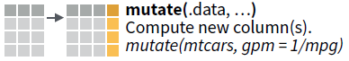

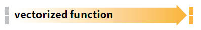

Modifica o añade columnas al data.frame

Es muy importante entender bien el funcionamiento de este comando ya que es uno de los más utilizados en el tratamiento de datos. mutate admite muchas `funciones`, algunas de las cuales os mencionamos a continuación, por ser las de uso más frecuente:

- Operadores aritméticos: **+, -, * , /, ^**
- Comparaciones lógicas: **<, <=, >, >=, !=, ==** a veces interesa almacenar los valores provisionales en nuevas variables para que puedas comprobar que cada paso funciona como se espera.
- Retardos: **lead() y lag()** te permiten referirte a un valor adelante o un valor atrás (con retardo).
- Agregados acumulativos y móviles:**cumsum(), cumprod(), cummin(), cummax(), cummean()**
- Otros comandos: este apartado tiene especial importancia ya que se encuentran comandos muy utilizados en el tratamiento de datos como son **recode()** o **if_else()**

Para consultar un listado más completo de las funciones disponibles, os remitimos a la chuleta:

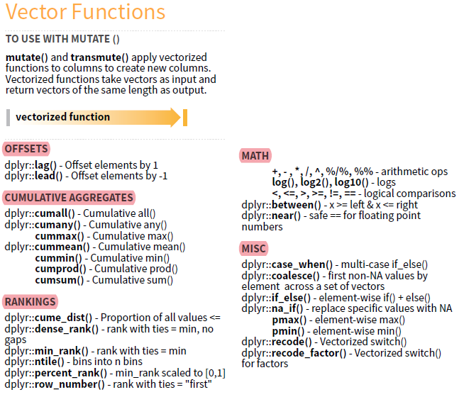

### Crear columnas

Como hemos dicho, mutate permite crear columnas nuevas a partir de otras. En la base de datos de **ikea** el precio de los artículos lo tenemos en riyales saudíes y queremos incluir una columna con el precio en euros (sabiendo que 1 riyal = 0.225 euros). Para ello, en primer lugar vamos a seleccionar las columnas item_id, name y price, es decir, el identificador del artículo, el nombre y el precio. Después creamos en el data.frame *Ejemplo*, una nueva columna precio_e que almacenará el precio en euros. Como veis, nuestra tabla final tiene las 3 variables que hemos seleccionado y la columna nueva calculada.

```r
Ejemplo <- ikea %>% select(item_id, name, price) %>% mutate(precio_e = price*0.225)
head(Ejemplo)
```

```
## # A tibble: 6 x 4
##    item_id name                  price precio_e
##      <dbl> <chr>                 <dbl>    <dbl>
## 1 90420332 FREKVENS                265     59.6
## 2   368814 NORDVIKEN               995    224.
## 3  9333523 NORDVIKEN / NORDVIKEN  2095    471.
## 4 80155205 STIG                     69     15.5
## 5 30180504 NORBERG                 225     50.6
## 6 10122647 INGOLF                  345     77.6
```

### Recodificar

En el tratamiento de datos es frecuente recodificar los datos para obtener la información resumida, agregada o descrita de otra forma. De este modo podríamos modificar la variable que nos indica si se puede comprar el artículo de ikea en internet (sellable_online) como 1 si su valor es TRUE y 0 si es FALSE. Para ello nos quedamos solo con las columnas item_id, name y sellable_online.

```r
Ejemplo <- ikea %>% select(item_id, name, sellable_online) %>% mutate(sellable_online=if_else(sellable_online=='TRUE',1,0))
head(Ejemplo)
```

```
## # A tibble: 6 x 3
##    item_id name                  sellable_online
##      <dbl> <chr>                           <dbl>
## 1 90420332 FREKVENS                            1
## 2   368814 NORDVIKEN                           0
## 3  9333523 NORDVIKEN / NORDVIKEN               0
## 4 80155205 STIG                                1
## 5 30180504 NORBERG                             1
## 6 10122647 INGOLF                              1
```

### Renombrar columnas

Para el tratamiento de columnas existe otro comando también muy útil `rename`. Con frecuencia nos interesa cambiar el nombre a las columnas de un data.frame. Tened en cuenta que programando, al resultado se puede llegar por varios caminos, es decir, podríamos cambiar el nombre a las columnas con un select.

Comando

Utilidad

Descripción

`rename()`

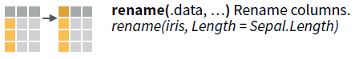

Renombra las variables o columnas

Por ejemplo si queremos sustituir los nombres en inglés por nombres en español de las variables item_id, name y price del fichero **ikea**, podríamos renombrarlas con el comando `rename()`

```r
Ejemplo <- ikea  %>% select(item_id, name, price)%>%
                     rename(identificador = item_id,
                            nombre        = name,
                            precio        = price)
head(Ejemplo)
```

```
## # A tibble: 6 x 3
##   identificador nombre                precio
##           <dbl> <chr>                  <dbl>
## 1      90420332 FREKVENS                 265
## 2        368814 NORDVIKEN                995
## 3       9333523 NORDVIKEN / NORDVIKEN   2095
## 4      80155205 STIG                      69
## 5      30180504 NORBERG                  225
## 6      10122647 INGOLF                   345
```

O de forma equivalente:

```r
Ejemplo <- ikea  %>% select(identificador = item_id,
                            nombre        = name,
                            precio        = price)
head(Ejemplo)
```

```
## # A tibble: 6 x 3
##   identificador nombre                precio
##           <dbl> <chr>                  <dbl>
## 1      90420332 FREKVENS                 265
## 2        368814 NORDVIKEN                995
## 3       9333523 NORDVIKEN / NORDVIKEN   2095
## 4      80155205 STIG                      69
## 5      30180504 NORBERG                  225
## 6      10122647 INGOLF                   345
```

En R y como suele ocurrir en la mayoría de los lenguajes de programación, no solo hay una forma de hacer las cosas.

# Preguntas de auto-evaluación

El objetivo de las siguientes preguntas es que podáis auto-evaluar si habéis adquirido los conocimientos. Encontraréis las respuestas en la pestaña de soluciones.

Para la resolución de algunos de estos ejercicios es necesario utilizar los ficheros planos del censo de 2011 que os hemos facilitado.

- **Pregunta 1**. ¿Cuáles de los siguientes comandos **no** se utiliza para manejar variables?
  1. select()
  2. mutate()
  3. distinct()
  4. rename()
- **Pregunta 2**. Con los siguientes datos, calcula el porcentaje de población de Sevilla sobre el total de Andalucía (en %) para los años 2020 y 2021.

  ```r
  df = data.frame(Año       = c(2020,2021),
                  Sevilla   = c(1950219,1946452),
                  Andalucía = c(8464411,8465236))
  ```

  1. -23.04 y -22.99
  2. 23.40 y 23
  3. 23.04 y 22.99
  4. 22.5 y 23
- **Pregunta 3**. Los datos de este data.frame muestran la serie de población de Andalucía desde 1980 hasta 2020. Calcula la tasa de variación de la población entre 2010 y 2020.

  ```r
  df = data.frame(Anno = c(1980,1990,2000,2010,2020),
                  pob  = c(6410209,6898938,7340052,8370975,8464411))
  ```

  1. No se puede calcular
  2. 14.05%
  3. 1.12%
  4. -1.12%
- **Pregunta 4**. Con los datos del Censo 2011. ¿Qué dos comandos tendríamos que encadenar mediante tuberías para conseguir la siguiente recodificación de la variable EDAD del fichero **DATOS_HP**?: 1=“Menores de 16 años” 2=“De 16 a 64 años” 3=“De 65 años o más”
  1. mutate y recode
  2. mutate y rename
  3. mutate e if_else
  4. A y C son ciertas
- **Pregunta 5**. Seleccionando del fichero de viviendas **DATOS_VE** las variables CPRO, CMUN y las que hagan referencia al número de plantas del edificio (usa el comando “starts_with” de la chuleta de dplyr). ¿Cuántas columnas tiene el data.frame final?
  1. 2
  2. 4
  3. 6
  4. No se puede calcular

# Soluciones

A continuación se muestran, marcadas y en rojo, las soluciones a las preguntas de auto-evaluación

- **Pregunta 1**. ¿Cuáles de los siguientes comandos **no** se utiliza para manejar variables?
  1. select()
  2. mutate()
  3. **distinct()**
  4. rename()
- **Pregunta 2**. Con los siguientes datos, calcula el porcentaje de población de Sevilla sobre el total de Andalucía (en %) para los años 2020 y 2021.

  ```r
  df = data.frame(Año       = c(2020,2021),
                  Sevilla   = c(1950219,1946452),
                  Andalucía = c(8464411,8465236))
  ```

  1. -23.04 y -22.99
  2. 23.40 y 23
  3. **23.04 y 22.99**
  4. 22.5 y 23

  **En concreto, hemos utilizado el siguiente código para obtener el resultado:**

  ```r
  Pregunta2 <- df %>% mutate(Porcentaje=round((Sevilla/Andalucía),4)*100)
  ```

- **Pregunta 3**. Los datos de este data.frame muestran la serie de población de Andalucía desde 1980 hasta 2020. Calcula la tasa de variación de la población entre 2010 y 2020.

  ```r
  df = data.frame(Anno = c(1980,1990,2000,2010,2020),
                  pob  = c(6410209,6898938,7340052,8370975,8464411))
  ```

  1. No se puede calcular
  2. 14.05%
  3. **1.12%**
  4. -1.12%

  **En concreto, hemos utilizado el siguiente código para obtener el resultado:**

  ```r
  Pregunta3 <- df %>% mutate(tv=round((pob/lag(pob)-1)*100,2))
  ```

- **Pregunta 4**. Con los datos del Censo 2011. ¿Qué dos comandos tendríamos que encadenar mediante tuberías para conseguir la siguiente recodificación de la variable EDAD del fichero **DATOS_HP**?: 1=“Menores de 16 años” 2=“De 16 a 64 años” 3=“De 65 años o más”
  1. mutate y recode
  2. mutate y rename
  3. mutate e if_else
  4. **A y C son ciertas**

  **En concreto, hemos utilizado el siguiente código para obtener el resultado:**

  ```r
  Pregunta4_A <- DATOS_HP %>%  mutate(EDAD=cut(as.numeric(EDAD), breaks=c(0,15,64,150),include.lowest=TRUE))%>%    #Usamos el comando cut para establecer los límites de los intervalos.
                               mutate(EDAD_R= recode(EDAD, "[0,15]" = '1' , '(15,64]' = '2'  , '(64,150]'  = '3') )#Una vez creados lo intervalos, se recodifican tal cual se indica en el ejercicio.

  Pregunta4_C <- DATOS_HP %>% mutate(EDAD=as.numeric(EDAD)) %>% mutate(EDAD_R=if_else(EDAD<16,'1',if_else(EDAD<65,'2','3')))
  ```

- **Pregunta 5**. Seleccionando del fichero de viviendas **DATOS_VE** las variables CPRO, CMUN y las que hagan referencia al número de plantas del edificio (usa el comando “starts_with” de la chuleta de dplyr). ¿Cuántas columnas tiene el data.frame final?
  1. 2
  2. **4**
  3. 6
  4. No se puede calcular

  **En concreto, hemos utilizado el siguiente código para obtener el resultado:**

  ```r
  Pregunta5 <- DATOS_VE %>% select(CPRO,CMUN,starts_with('PLANT'))
  ```